# Dr T's experiential knowledge for Pro Data Science , for Pro level ML Next Gen engineers

### 📊 Step 6: Exploratory Data Analysis (EDA)

#### 📘 **Explanation:**

Exploratory Data Analysis (EDA) is crucial for uncovering patterns, anomalies, relationships, and trends in the data, which can influence hypotheses and modeling approaches. EDA typically involves visualizing data through various graphs and statistical summaries to gain deeper insights into the dataset's underlying structure and dynamics.

#### 💻 **Code:

```
import seaborn as sns
import matplotlib.pyplot as plt

# Creating a histogram for the 'salary_in_usd' column to observe its distribution
plt.figure(figsize=(10, 6))
plt.hist(data['salary_in_usd'], bins=30, color='blue', alpha=0.7)
plt.title('Distribution of Salaries in USD')
plt.xlabel('Salary in USD')
plt.ylabel('Frequency')
plt.grid(True)
plt.show()

# Generating a correlation matrix to explore potential relationships between numerical features
plt.figure(figsize=(10, 8))
sns.heatmap(data.corr(), annot=True, cmap='coolwarm', fmt=".2f")
plt.title('Correlation Matrix of Features')
plt.show()
```

**What's Happening:**

- **Histogram:** The histogram is used to visualize the distribution of numerical data, here representing salaries. It helps in understanding the spread and central tendencies of salary values.
- **Correlation Matrix:** This heatmap represents the correlation coefficients between numerical variables in the dataset. It is useful for detecting potential relationships or multicollinearity between features, which can inform feature selection for modeling.

EDA provides a foundation for all subsequent analyses and is instrumental in guiding the choice of data preprocessing and modeling techniques. If you're ready to continue to the next step, just say "continue".

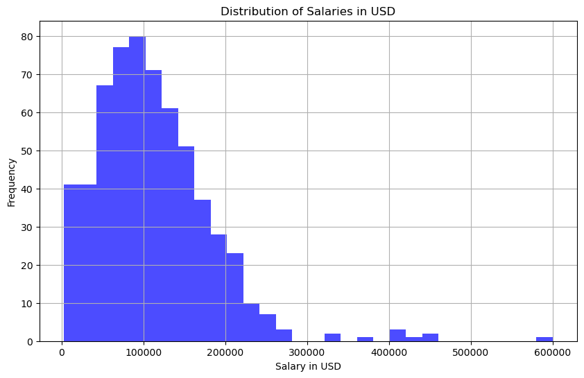

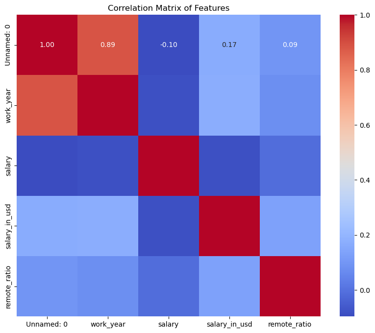

```python
import seaborn as sns
import matplotlib.pyplot as plt

# Creating a histogram for the 'salary_in_usd' column to observe its distribution
plt.figure(figsize=(10, 6))
plt.hist(data['salary_in_usd'], bins=30, color='blue', alpha=0.7)
plt.title('Distribution of Salaries in USD')
plt.xlabel('Salary in USD')
plt.ylabel('Frequency')
plt.grid(True)
plt.show()

# Generating a correlation matrix to explore potential relationships between numerical features
plt.figure(figsize=(10, 8))
sns.heatmap(data.corr(), annot=True, cmap='coolwarm', fmt=".2f")
plt.title('Correlation Matrix of Features')
plt.show()
```

# Dr T's experiential knowledge for Pro Data Science , for Pro level ML Next Gen engineers

understanding the data to maximum benefits - eda - pre prepare for

1. u take the columns and categorical or numerical columns
2. then u plan , based on bussiness requirements , that is what clients , want and what we have to plan for
3. easy is take the categorical x numerical = total number of insights that can be generated .

4)plan for chat gpt help , or self plan to deal with actionable insights or relevant understanding the data

5)plan all the insights and serve all the total combinations as will or direct it to only bussiness case study as recommended . 6)Then continue with EDA and etc live showcasing .

7)prepare , based on bussiness case study for ML on bussiness case requirements of regression,classification,ensemble,clustering(followed by r or c or e),associations,reenforcement,nlp,DL,Genai,Agent AI , TL etc

### Machine Learning (ML) Business Case Study Breakdown:

In the context of a **business case study**, different types of **machine learning models** are employed to solve specific business problems. The requirements of the business often guide which model is most appropriate for addressing the goals, whether it's predictive analytics, clustering for customer segmentation, or understanding consumer sentiment via NLP. Below, I'll break down how each **type of machine learning model** applies to a business case, along with **use cases** and **expected outcomes**.

### **1) Regression (R)**

**Business Case**: **Predicting Sales or Revenue**  
**Goal**: Predict continuous numeric values such as sales, revenue, or market demand over time.

#### **Use Case**:

- **Predicting Monthly Sales**: A retail business wants to predict the monthly sales for the upcoming quarter based on historical data.
  - **Feature Data**: Time, marketing spend, previous sales, seasonality, promotions.
  - **Model Type**: Linear Regression, Decision Trees, Random Forest.
  - **Outcome**: Predict future sales to optimize inventory and staffing.

#### **Business Requirements**:

- **Accuracy**: High accuracy in predicting sales trends.
- **Key Metrics**: RMSE (Root Mean Square Error), MAE (Mean Absolute Error).

#### **ML Model**: **Linear Regression**, **Random Forest Regression**, **Gradient Boosting Regression**.

### **2) Classification (C)**

**Business Case**: **Customer Churn Prediction**  
**Goal**: Classify customers into categories (e.g., churn vs. non-churn) based on historical behaviors.

#### **Use Case**:

- **Customer Retention**: A telecom company wants to predict which customers are likely to cancel their subscription.
  - **Feature Data**: Customer usage patterns, contract type, support calls, demographics.
  - **Model Type**: Logistic Regression, Decision Trees, Support Vector Machines (SVM).
  - **Outcome**: Identify high-risk customers and take actions (e.g., offer discounts, targeted marketing).

#### **Business Requirements**:

- **Accuracy**: A focus on minimizing false positives (non-churn customers wrongly predicted as churn).
- **Key Metrics**: Accuracy, Precision, Recall, F1 Score.

#### **ML Model**: **Logistic Regression**, **Random Forest Classifier**, **XGBoost**.

### **3) Ensemble Learning (E)**

**Business Case**: **Fraud Detection**  
**Goal**: Combine multiple models to improve the prediction accuracy of fraud detection.

#### **Use Case**:

- **Financial Fraud**: A bank wants to detect fraudulent transactions using a combination of decision trees, boosting, and bagging models.
  - **Feature Data**: Transaction amount, merchant, user profile, device type, geographical location.
  - **Model Type**: Random Forest, Gradient Boosting, AdaBoost.
  - **Outcome**: Higher accuracy and reduced overfitting by combining multiple models.

#### **Business Requirements**:

- **Accuracy and Robustness**: Ensuring that all models contribute to reducing false positives and negatives.
- **Key Metrics**: Accuracy, AUC-ROC (Area Under Curve – Receiver Operating Characteristic).

#### **ML Model**: **Random Forest**, **XGBoost**, **AdaBoost**.

### **4) Clustering (C)**

**Business Case**: **Customer Segmentation**  
**Goal**: Group customers into distinct clusters for targeted marketing.

#### **Use Case**:

- **Market Segmentation**: A retailer wants to segment its customers based on purchasing behavior for targeted advertising.
  - **Feature Data**: Purchase frequency, product categories, average order value, demographics.
  - **Model Type**: K-means Clustering, DBSCAN, Hierarchical Clustering.
  - **Outcome**: Create marketing strategies tailored to each customer segment.

#### **Business Requirements**:

- **Segment Analysis**: Ability to group customers into meaningful segments for personalized marketing.
- **Key Metrics**: Silhouette Score, Dunn Index, Elbow Method.

#### **ML Model**: **K-means Clustering**, **DBSCAN**.

### **5) Associations (A)**

**Business Case**: **Market Basket Analysis**  
**Goal**: Discover associations between products bought together to optimize cross-selling strategies.

#### **Use Case**:

- **Recommendation Engine**: An e-commerce platform wants to identify frequently bought products together to suggest bundled offers.
  - **Feature Data**: Transaction data, product category, purchase history.
  - **Model Type**: Apriori Algorithm, FP-Growth.
  - **Outcome**: Discover frequent itemsets (e.g., customers who bought product A also bought product B).

#### **Business Requirements**:

- **Relevance**: Identifying relevant associations that can be used for product recommendations.
- **Key Metrics**: Support, Confidence, Lift.

#### **ML Model**: **Apriori**, **FP-Growth**.

### **6) Reinforcement Learning (RL)**

**Business Case**: **Dynamic Pricing**  
**Goal**: Implement dynamic pricing that maximizes revenue based on customer interactions.

#### **Use Case**:

- **Optimizing Pricing Strategy**: An airline uses reinforcement learning to dynamically adjust ticket prices based on demand, competition, and user behavior.
  - **Feature Data**: Price elasticity, booking behavior, time to flight, competition prices.
  - **Model Type**: Q-learning, Deep Q Networks (DQN), Policy Gradient Methods.
  - **Outcome**: Learn the optimal pricing strategy over time through interactions with the environment.

#### **Business Requirements**:

- **Real-Time Decision Making**: Need for real-time adjustments to pricing strategy based on external variables.
- **Key Metrics**: Reward Function, Cumulative Return, Exploration vs. Exploitation.

#### **ML Model**: **Q-learning**, **Deep Q Networks (DQN)**.

### **7) Natural Language Processing (NLP)**

**Business Case**: **Customer Sentiment Analysis**  
**Goal**: Analyze customer feedback to determine overall sentiment (positive, neutral, or negative).

#### **Use Case**:

- **Social Media Monitoring**: A brand wants to analyze Twitter posts and customer reviews to gauge sentiment about their products.
  - **Feature Data**: Text data from social media posts, customer reviews, product feedback.
  - **Model Type**: Text Classification, Sentiment Analysis, Named Entity Recognition (NER).
  - **Outcome**: Provide actionable insights for marketing and customer service.

#### **Business Requirements**:

- **Accuracy**: Extract useful insights from raw text data.
- **Key Metrics**: Accuracy, Precision, Recall, F1-Score, AUC.

#### **ML Model**: **Naive Bayes**, **LSTM (Long Short-Term Memory)**, **BERT**.

### **8) Deep Learning (DL)**

**Business Case**: **Image Recognition**  
**Goal**: Identify objects within images for automation and quality control.

#### **Use Case**:

- **Automated Defect Detection**: A manufacturing company uses deep learning to identify defective products on a production line via images captured by cameras.
  - **Feature Data**: Pixel data from images of products.
  - **Model Type**: Convolutional Neural Networks (CNN), Autoencoders.
  - **Outcome**: Automate quality control, reducing human error and operational costs.

#### **Business Requirements**:

- **Real-Time Processing**: Speed and accuracy in identifying defects from high-volume image data.
- **Key Metrics**: Accuracy, Precision, Recall, F1-Score, Confusion Matrix.

#### **ML Model**: **CNN**, **ResNet**, **VGG16**.

### **9) Generative AI (GenAI)**

**Business Case**: **Content Generation**  
**Goal**: Automatically generate high-quality content like product descriptions, blog posts, or marketing copy.

#### **Use Case**:

- **Product Descriptions for E-commerce**: An e-commerce company uses Generative AI to automatically generate product descriptions from short product titles or specifications.
  - **Feature Data**: Product features, keywords, categories.
  - **Model Type**: GPT-3, BERT, T5 (Text-to-Text Transfer Transformer).
  - **Outcome**: Generate engaging and relevant content, reducing manual effort and scaling marketing operations.

#### **Business Requirements**:

- **Creativity and Coherence**: Ensure generated content is contextually appropriate and relevant.
- **Key Metrics**: BLEU Score, ROUGE Score (for text generation evaluation).

#### **ML Model**: **GPT-3**, **BERT**, **T5**.

### **Summary of ML Business Case Requirements:**

| **Business Need** | **Model Type** | **Key Metrics/Approach** |
| --- | --- | --- |
| Predict sales and trends | Regression (R) | RMSE, MAE |
| Customer churn prediction | Classification (C) | Accuracy, Precision, Recall |
| Fraud detection | Ensemble Learning (E) | AUC-ROC, Accuracy |
| Customer segmentation | Clustering (C) | Silhouette Score, Dunn Index |
| Market basket analysis | Association (A) | Support, Confidence, Lift |
| Dynamic pricing | Reinforcement Learning (RL) | Cumulative Return, Reward |
| Sentiment analysis | NLP | Accuracy, F1-Score |
| Image recognition | Deep Learning (DL) | Accuracy, Precision, Recall |
| Content generation | Generative AI (GenAI) | BLEU Score, ROUGE Score |

In addition to the machine learning techniques discussed previously, there are several other advanced AI and machine learning methods that can be applied to solve specific business problems. Here's an extended breakdown that includes **Agent AI**, **Reinforcement Learning in a broader sense**, and other **AI techniques** relevant to business cases.

### **10) Agent-Based AI (Agent AI)**

**Business Case**: **Autonomous Decision-Making and Task Automation** **Goal**: Create intelligent agents that can make decisions and perform tasks autonomously based on environment interactions.

#### **Use Case**:

- **Autonomous Robots in Warehouses**: A logistics company wants to automate the movement of packages in a warehouse using autonomous robots (agents). These agents learn from their environment to avoid obstacles, pick up packages, and place them in the correct locations.
  - **Feature Data**: Sensors data, location, obstacles, package sizes.
  - **Model Type**: Multi-Agent Systems (MAS), Reinforcement Learning, Q-learning.
  - **Outcome**: Improve warehouse operations, reduce human labor costs, and increase operational efficiency.

#### **Business Requirements**:

- **Adaptability**: Agents must learn and adapt to the dynamic environment of the warehouse.
- **Key Metrics**: Task completion rate, error rate, time to completion.

#### **ML Model**: **Multi-Agent Systems (MAS)**, **Deep Q Networks (DQN)**, **Reinforcement Learning (RL)**.

### **11) Transfer Learning (TL)**

**Business Case**: **Improved Model Training Efficiency** **Goal**: Apply knowledge from one task (source domain) to a different but related task (target domain) to improve model performance without needing to train from scratch.

#### **Use Case**:

- **Medical Image Classification**: A hospital uses a model trained on general images (e.g., from ImageNet) to identify specific medical conditions in X-ray or MRI images.
  - **Feature Data**: X-ray images, MRI scans, medical labels.
  - **Model Type**: Convolutional Neural Networks (CNN) with transfer learning from pre-trained models.
  - **Outcome**: Save on model training time and resources while achieving high accuracy in specific medical tasks.